# Testing R Markdown

31 de octubre de 2017

# Hands-on

## Code and code shunks

I have 4.6666667 apples

```
Call:
lm(formula = mpg ~ disp + hp, data = mtcars)

Residuals:
    Min      1Q  Median      3Q     Max
-4.7945 -2.3036 -0.8246  1.8582  6.9363

Coefficients:
             Estimate Std. Error t value Pr(>|t|)
(Intercept) 30.735904   1.331566  23.083  < 2e-16 ***
disp        -0.030346   0.007405  -4.098 0.000306 ***
hp          -0.024840   0.013385  -1.856 0.073679 .
---
Signif. codes:  0 ‘***’ 0.001 ‘**’ 0.01 ‘*’ 0.05 ‘.’ 0.1 ‘ ’ 1

Residual standard error: 3.127 on 29 degrees of freedom
Multiple R-squared:  0.7482,    Adjusted R-squared:  0.7309
F-statistic: 43.09 on 2 and 29 DF,  p-value: 2.062e-09
```

The intercept is 30.7359042

## References

You need:

- A BibTeX file (provided in the CourseMaterials folder)
- Specify `bibliography:` and `csl:` in the header
- That’s it…

“A tidy dataset has a column for each variable” [1]

**References**

1. Wickham H. Tidy data. J Stat Softw. 2014;59. doi:10.18637/jss.v059.i10

### Other resources for references

- [Citation style library](http://editor.citationstyles.org/about/)
- Tyler Clavelle has a great [tutorial](https://tclavelle.github.io/blog/reference_tips/) on this

## Code chunk options

- CHUNK NAMES!
- `echo` hides code from output
- `eval` evaluate chunk?
- `fig.width`
- `fig.height`
- `fig.cap` To add figure caption

## Fancier way to report models with `stargazer`

results = ‘asis’

```r
model2 <- lm(mpg ~ disp, mtcars)
stargazer::stargazer(model, model2, type = "html")
```

number of rows of result is not a multiple of vector length (arg 2)

|  | *Dependent variable:* |  |
| --- | --- | --- |
|  | mpg |  |
|  | (1) | (2) |
| disp | -0.030*** | -0.041*** |
|  | (0.007) | (0.005) |
| hp | -0.025* |  |
|  | (0.013) |  |
| Constant | 30.736*** | 29.600*** |
|  | (1.332) | (1.230) |
| Observations | 32 | 32 |
| R<sup>2</sup> | 0.748 | 0.718 |
| Adjusted R<sup>2</sup> | 0.731 | 0.709 |
| Residual Std. Error | 3.127 (df = 29) | 3.251 (df = 30) |
| F Statistic | 43.095*** (df = 2; 29) | 76.513*** (df = 1; 30) |
| *Note:* | p<0.1; p<0.05; p<0.01 |  |

## Fancier way to report models with `stargazer`

```r
stargazer::stargazer(model, model2,
                     single.row = T,
                     type = "html",
                     omit.stat = "rsq")
```

number of rows of result is not a multiple of vector length (arg 2)

|  | *Dependent variable:* |  |
| --- | --- | --- |
|  | mpg |  |
|  | (1) | (2) |
| disp | -0.030*** (0.007) | -0.041*** (0.005) |
| hp | -0.025* (0.013) |  |
| Constant | 30.736*** (1.332) | 29.600*** (1.230) |
| Observations | 32 | 32 |
| Adjusted R<sup>2</sup> | 0.731 | 0.709 |
| Residual Std. Error | 3.127 (df = 29) | 3.251 (df = 30) |
| F Statistic | 43.095*** (df = 2; 29) | 76.513*** (df = 1; 30) |
| *Note:* | p<0.1; p<0.05; p<0.01 |  |

Modify stargazer with title, singe.row, covariate.labels, omit.stat

- Awesome [examples by Jake Russ](http://www.jakeruss.com/cheatsheets/stargazer/)

## Figures with code

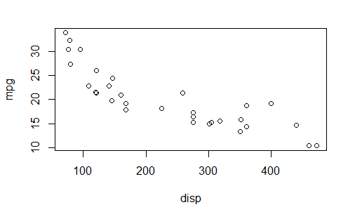

```r
plot(mtcars$disp, mtcars$mpg,xlab = "disp", ylab = "mpg")
```

Plot disp vs mpg

## Tables

Create raw markdown table

| Title 1 | Title 2 |
| --- | --- |
| Element 1 | Element 2 |
| Element 1 | Element 2 |
| Element 1 | Element 2 |
| Element 1 | Element 2 |
| Element 1 | Element 2 |

## Tables with `knitr` and `kable`

Table from Data/taxa_table.csv and knitr

| Family | Genus | Species | Count | Surfers |
| --- | --- | --- | --- | --- |
| Pomacentridae | Hypsypops | rubicundus | 1 | 20 |
| Polyprionidae | Stereolepis | gigas | 2 | 18 |
| Scorpaenidae | Sebastes | hopkinsi | 30 | 10 |
| Scorpaenidae | Sebastes | paucispinis | 45 | 1 |
| Scorpaenidae | Pterois | volitans | 62 | 2 |
| Serranidae | Paralabrax | clathratus | 12 | 8 |
| Serranidae | Paralabrax | nebulifer | 15 | 12 |

Using the `taxa_table.csv` file in the `CourseMaterials`

## California’s State Fish

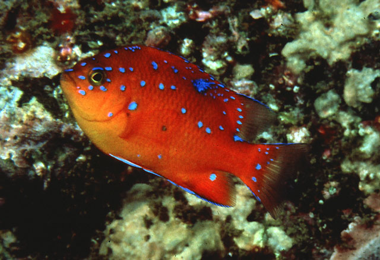

Juvenile Garibaldi (*Hypsypops rubicundus*)

- October 15, 1995, Adopted as the California State Marine Fish

## Fancier tables with `kableExtra`

But scientific names (*Genus species*) are supposed to be in italics!

| Family | Genus | Species | Count | Surfers |
| --- | --- | --- | --- | --- |
| Pomacentridae | Hypsypops | rubicundus | 1 | 20 |
| Polyprionidae | Stereolepis | gigas | 2 | 18 |
| Scorpaenidae | Sebastes | hopkinsi | 30 | 10 |
| Scorpaenidae | Sebastes | paucispinis | 45 | 1 |
| Scorpaenidae | Pterois | volitans | 62 | 2 |
| Serranidae | Paralabrax | clathratus | 12 | 8 |
| Serranidae | Paralabrax | nebulifer | 15 | 12 |

- Specify format by columns

## Fancier tables with `kableExtra`

- Collapse rows for clarity

| Family | Genus | Species | Count | Surfers |
| --- | --- | --- | --- | --- |
| Pomacentridae | Hypsypops | rubicundus | 1 | 20 |
| Polyprionidae | Stereolepis | gigas | 2 | 18 |
| Scorpaenidae | Sebastes | hopkinsi | 30 | 10 |
|  | Sebastes | paucispinis | 45 | 1 |
|  | Pterois | volitans | 62 | 2 |
| Serranidae | Paralabrax | clathratus | 12 | 8 |
|  | Paralabrax | nebulifer | 15 | 12 |

```r
plot(sdjfkjs)
```

## If there is time

Do one of the following assignments. Should be less than 5 minutes

- Create an html document:
  - Title
  - Subtitle
  - Author
  - Headers and subheader
  - A list with bullets
  - Text with old and itallics
  - 1 plot (nothing meaningful, invent something or use existing data)
  - 1 `knitr` + `kableExtra` table
- Extra:
  - Include an equation
  - Code doesn’t show
  - Include at least 1 reference from the BibTex file

## Resources

- Intro to R Markdown:
  - [Tutorial](http://rmarkdown.rstudio.com/lesson-1.html)
- YAML options:
  - See [options for HTML](http://rmarkdown.rstudio.com/html_document_format.html)
  - See [options for PDF](http://rmarkdown.rstudio.com/pdf_document_format.html)
- References
  - [Citation style library](http://editor.citationstyles.org/about/)
  - Tyler Clavelle’s [tutorial](https://tclavelle.github.io/blog/reference_tips/)
- Stargazer
  - Jake Russ’ [cheatsheet](http://www.jakeruss.com/cheatsheets/stargazer/)
- kableExtra
  - [For HTML output](http://haozhu233.github.io/kableExtra/awesome_table_in_html.html)
  - [For PDF output](http://haozhu233.github.io/kableExtra/awesome_table_in_pdf.pdf)